# Coding Cookbook

Engineering Statistics I (MA223)

This document provides a list of the code most commonly used in the course. There may be times, especially when working on an independent capstone project, when you want to move beyond what is discussed in class. There are many resources available online, or feel free to ask for guidance from the instructor. However, the majority of code needed for the course is documented here.

Throughout this document, we will be making use of the `mtcars` dataset available with all R installations. More information can be found about the variables in this dataset by typing `?mtcars` into your R console or typing `mtcars` into the help search box in RStudio. Here are the first few records of the dataset:

|  | mpg | cyl | disp | hp | drat | wt | qsec | vs | am | gear | carb |
| --- | --- | --- | --- | --- | --- | --- | --- | --- | --- | --- | --- |
| Mazda RX4 | 21.0 | 6 | 160 | 110 | 3.90 | 2.620 | 16.46 | 0 | 1 | 4 | 4 |
| Mazda RX4 Wag | 21.0 | 6 | 160 | 110 | 3.90 | 2.875 | 17.02 | 0 | 1 | 4 | 4 |
| Datsun 710 | 22.8 | 4 | 108 | 93 | 3.85 | 2.320 | 18.61 | 1 | 1 | 4 | 1 |
| Hornet 4 Drive | 21.4 | 6 | 258 | 110 | 3.08 | 3.215 | 19.44 | 1 | 0 | 3 | 1 |
| Hornet Sportabout | 18.7 | 8 | 360 | 175 | 3.15 | 3.440 | 17.02 | 0 | 0 | 3 | 2 |
| Valiant | 18.1 | 6 | 225 | 105 | 2.76 | 3.460 | 20.22 | 1 | 0 | 3 | 1 |

As you progress through the following examples, remember that R is *case sensitive*.

# Basics

Before proceeding to the specific aspects of the course; let’s first talk about a few basics about programming in R.

## Packages

Throughout the course we will be using a standard suite of packages (additional functions which provide additional analytical capabilities). In order to ensure that you have all required functionality for the course, be sure that each RMarkdown file you write has the following block at the top, which should not be altered:

```r
IntroAnalysis:::ma223_setup()
```

## Anatomy of RMarkdown File

An RMarkdown file is comprised of two components: basic text and “code chunks” which perform the analysis. When the document is compiled (“knit”) the code is evaluated and the results added seemlessly into your document. This encourages a reproducible workflow (someone can recreate all your results should the data change).

Code blocks can be added using the “Insert” button at the top of the script window. Code blocks have the following form:

````
```{r}
Code goes here...
```
````

Notice that the code blocks always begin and end with the triple backticks (found on your keyboard in the upper-left-hand corner with the tilde).

## Anatomy of R Code

Most code chunks all look the same. Below is a very simple code chunk. Objects are “assigned” to an object using an equal sign (or arrow `<-`). The code essentially says that the thing on the left will contain anything generated on the right.

```r
# Comments (not evaluated) begin with a hashtag.
ObjectName = code to generate results
```

> Just typing the name of an object prints that object out; that output, in turn, will appear in your final document.

If we want to do something to that object, we will make use of the “pipe operator” (`%>%`) which essentially says take the thing before and use it in the next function. For example, we might summarise an object as follows:

```r
ObjectTwo = ObjectOne %>%
  summarise()
```

This code says take the thing called “ObjectOne” and “pipe it into” (use within) the summarise function; whatever the result of this operation is will be called “ObjectTwo.”

## Creating a Dataset from Scratch

Occasionally, you may need to input data manually (generally, data will be provided to you). This is done using the `tibble()` function. Things to keep in mind include

- Variables are separated by commas.
- Each variable must be named (`Variable_Name =`).
- Values are separated by commas and placed inside the `c()` function.
- Values of a categorical variable are placed inside quotes.

Here is a hypothetical example in which the results of a simple survey are entered into a dataset called `demographics`.

```r
demographics = tibble(
  `Hair Color` = c("Black", "Black", "Brown", "Blonde", "Black"),
  Age = c(20, 19, 21, 20, 20)
)
```

## Reading in a Dataset from Moodle

Occasionally, you will need to load data stored in a spreadsheet that exists on Moodle. First, you will need to upload that dataset to RStudio. Perform the following steps:

1. Navigate to the dataset in Moodle and download it to your local machine (generally, it will be stored in your machine’s “Downloads” folder).
2. Open RStudio; in the lower-right panel, find the “Files” tab and click into the folder where you want your dataset. Then, click on “Upload” and navigate to the file on your machine. This will upload the file from your local machine to RStudio.

[figure not shown]

Now that you have the dataset in RStudio, you will need to load it into your Rmarkdown file. To do that, you will generally use `read_csv()`:

```r
mydata = read_csv("Dataset.csv")
```

Note the *file* is called `Dataset.csv`, but the *object* in which the dataset is stored is called `mydata`. The left-hand side is the name we give the dataset, and the right-hand side refers to the file name. You can make these the same if you would like. The above assumes the file is a `csv` file. If you have an Excel worksheet, you will want to use the following code.

```r
mydata = readxl::read_excel("Dataset.xlsx")
```

I recommend always saving a spreadsheet as a CSV file for portability. You can do that in Excel by clicking “File > Save As” in the menu system.

[figure not shown]

# Data Manipulation

Data is rarely perfect when we first obtain it. Often times, we will need to make changes. There are a few tasks which are performed regularly; these can generally be accomplished with the following two functions:

- `mutate()`: manipulate variables or make transformations.
- `filter()`: subset the data based on some criteria.

## mutate(): creating or changing variables

As an example, while the US measures fuel efficiency in miles per gallon, other countries often report the gallons required for a single mile. This new variable `Gallons_per_Mile` can be created using `mutate()`:

```r
mtcars = mtcars %>%
  mutate(Gallons_per_Mile = 1/mpg)
```

Notice that we use the pipe operator (`%>%`) here; this essentially says take the dataset `mtcars` and feed it into the `mutate()` function. The `mutate()` function itself uses the notation `New_Variable_Name = transformation of stuff`. In this case, we create a new variable within the dataset `mtcars`. The result is stored within a dataset called `mtcars` (since that is on the left of the equal sign), essentially overwriting the original dataset.

The first few records of this dataset are shown below:

| mpg | cyl | disp | hp | drat | wt | qsec | vs | am | gear | carb | Gallons_per_Mile |
| --- | --- | --- | --- | --- | --- | --- | --- | --- | --- | --- | --- |
| 21.0 | 6 | 160 | 110 | 3.90 | 2.620 | 16.46 | 0 | 1 | 4 | 4 | 0.048 |
| 21.0 | 6 | 160 | 110 | 3.90 | 2.875 | 17.02 | 0 | 1 | 4 | 4 | 0.048 |
| 22.8 | 4 | 108 | 93 | 3.85 | 2.320 | 18.61 | 1 | 1 | 4 | 1 | 0.044 |
| 21.4 | 6 | 258 | 110 | 3.08 | 3.215 | 19.44 | 1 | 0 | 3 | 1 | 0.047 |
| 18.7 | 8 | 360 | 175 | 3.15 | 3.440 | 17.02 | 0 | 0 | 3 | 2 | 0.053 |
| 18.1 | 6 | 225 | 105 | 2.76 | 3.460 | 20.22 | 1 | 0 | 3 | 1 | 0.055 |

## filter(): subsetting a variable

If we only want to look at a subset of the data, we use the `filter()` function. For example, suppose we only want to consider vehicles which have automatic transmissions. Further, we would like to store those in a new dataset called `automatic.only`, we use the following code:

```r
automatic.only = mtcars %>%
  filter(am == 0)
```

When making comparisons, `==` is asking “are you equal?” We keep the records for which we would anser “yes” to this question. The original `mtcars` dataset is not altered; it remains unchanged. Instead, we have taken it, filtered it down, and then stored the results in `automatic.only` (the first few records of which are shown below).

| mpg | cyl | disp | hp | drat | wt | qsec | vs | am | gear | carb | Gallons_per_Mile |
| --- | --- | --- | --- | --- | --- | --- | --- | --- | --- | --- | --- |
| 21.4 | 6 | 258.0 | 110 | 3.08 | 3.215 | 19.44 | 1 | 0 | 3 | 1 | 0.047 |
| 18.7 | 8 | 360.0 | 175 | 3.15 | 3.440 | 17.02 | 0 | 0 | 3 | 2 | 0.053 |
| 18.1 | 6 | 225.0 | 105 | 2.76 | 3.460 | 20.22 | 1 | 0 | 3 | 1 | 0.055 |
| 14.3 | 8 | 360.0 | 245 | 3.21 | 3.570 | 15.84 | 0 | 0 | 3 | 4 | 0.070 |
| 24.4 | 4 | 146.7 | 62 | 3.69 | 3.190 | 20.00 | 1 | 0 | 4 | 2 | 0.041 |
| 22.8 | 4 | 140.8 | 95 | 3.92 | 3.150 | 22.90 | 1 | 0 | 4 | 2 | 0.044 |

## recode(): Changing the values of a variable

When we work with categorical variables, we often want the values (or group labels) to be something readable. In order to do this, we may need to recode the data. Consider the variable `am` (transmission type). It is currently a 0/1 variable, and it is not obvious that 1 represents manual transmission and 0 automatic transmission. We can make this clearer by mutating the dataset and recoding that variable.

```r
mtcars = mtcars %>%
  mutate(am = recode(am,
                     `0` = "automatic",
                     `1` = "manual"))
```

There is a difference between backticks `` \`` and single quotes ``’`. In the above, the backticks are used because we are converting a number into a phrase. The first few records of the updated dataset are shown below:

| mpg | cyl | disp | hp | drat | wt | qsec | vs | am | gear | carb | Gallons_per_Mile |
| --- | --- | --- | --- | --- | --- | --- | --- | --- | --- | --- | --- |
| 21.0 | 6 | 160 | 110 | 3.90 | 2.620 | 16.46 | 0 | manual | 4 | 4 | 0.048 |
| 21.0 | 6 | 160 | 110 | 3.90 | 2.875 | 17.02 | 0 | manual | 4 | 4 | 0.048 |
| 22.8 | 4 | 108 | 93 | 3.85 | 2.320 | 18.61 | 1 | manual | 4 | 1 | 0.044 |
| 21.4 | 6 | 258 | 110 | 3.08 | 3.215 | 19.44 | 1 | automatic | 3 | 1 | 0.047 |
| 18.7 | 8 | 360 | 175 | 3.15 | 3.440 | 17.02 | 0 | automatic | 3 | 2 | 0.053 |
| 18.1 | 6 | 225 | 105 | 2.76 | 3.460 | 20.22 | 1 | automatic | 3 | 1 | 0.055 |

If we now wanted to go further and change “automatic” to “Automatic Transmission”, we could recode again; this time, since the variable is already a phrase, we do not use backticks.

```r
mtcars = mtcars %>%
  mutate(am = recode(am,
                     "automatic" = "Automatic Transmission",
                     "manual" = "Manual Transmission"))
```

> If your dataset has groups coded as numbers (like above when 0 = automatic and 1 = manual), it is best to recode in order for graphics and models to work appropriately.

# Numerical Summaries

Numerical summaries (statistics) tell us about the distribution of our sample. These also estimate the corresponding parameters of interest in the population. The functions we introduce below make use of “formula” notation in `R`. We take a second to introduce that here, and it will make more sense in the later modeling sections. Let’s compare two basic formulas:

1. `y ~ 1`
2. `y ~ group`

Both formulas have two essential components: a left-hand-side and a right-hand-side separated by the `~`. Think of the `~` as an “equal sign” in a mathematical formula or as a way of saying “related to.” The first formula says that the variable `y` is not related to anything; you are interested in summarizing it across all records. The second formula says you want to summarize the variable `y` within groups which are defined by the variable `group`.

Of course, the “variable `y`” is not very helpful unless you tell the computer where to look for that variable. So, formulas are often accompanied by a `data =` argument to allow you to specify the data set in which the variable is located.

## summarize_variable(): Summarizing a single variable.

The `summarize_variable()` function allows us to compute individual summaries of variables. The following code computes the average mpg of vehicles in the sample as well as the standard deviation.

```r
summarize_variable(mpg ~ 1, data = mtcars, mean, sd)
```

```
      mean       sd
1 20.09062 6.026948
```

The average fuel efficiency might differ for automatic and manual transmissions. In order to compute the above summaries for each type of car, we include the grouping variable.

```r
summarize_variable(mpg ~ am, data = mtcars, mean, sd)
```

```
                      am     mean       sd
1 Automatic Transmission 17.14737 3.833966
2    Manual Transmission 24.39231 6.166504
```

After the `data =` option, we specify key words for computing summaries. The most used key words are given in a table later in this section. to compute a proportion, we need to specify what value we want the proportion for:

```r
summarize_variable((am=="Manual Transmission") ~ 1, data = mtcars, percent)
```

```
  percent
1  40.625
```

## List of functions for numerical summaries

The following table contains a list of functions used to construct common summaries.

List of functions for numerical summaries

| Numerical Summary | Keyword/Function |
| --- | --- |
| Sample Size | `length` |
| Mean/Average | `mean` |
| Standard Deviation | `sd` |
| Median | `median` |
| Minimum | `min` |
| Maximum | `max` |
| 25-th Percentile | `Q1` |
| 75-th Percentile | `Q3` |
| Interquartile Range | `IQR` |
| Percent | `percent` |
| Proportion | `mean` |
| 1-st Percentile | `perc01` |
| 5-th Percentile | `perc05` |
| 10-th Percentile | `perc10` |
| 20-th Percentile | `perc20` |
| 80-th Percentile | `perc80` |
| 85-th Percentile | `perc85` |
| 90-th Percentile | `perc90` |
| 95-th Percentile | `perc95` |
| 99-th Percentile | `perc99` |

If missing values are present in the data, these summaries cannot be computed. In order to make the computations excluding the missing values, pass the argument `na.rm = TRUE` to the function:

```r
summarize_variable(mpg ~ 1, data = mtcars, mean, .args = list(na.rm = TRUE))
```

```
      mean
1 20.09062
```

## summarize_relationship(): Summarize the relationship between two variables.

When numerically summarizing the relationship between two variables, we are typically interested in computing the correlation coefficient relating two numeric variables. This is done with `summarize_relationship()`. The following code computes the correlation relating the fuel efficiency with the horsepower of the engine.

```r
summarize_relationship(mpg ~ hp, data = mtcars)
```

```
   statistic
1 -0.7761684
```

Again, the formula interface is used to suggest which two variables we are relating.

# Graphics

A picture is worth 1000 words. A good graphical summary of the data should not only be a first step in an analysis, but it should also accompany any good analysis to help convey the message of the data. All graphics in this class will be produced with the `qplot()` function. If you are interested in moving beyond what is described here, I would encourage you to look at the `ggplot2` package and would guide you toward the [Ggplot Cheat Sheet](https://www.rstudio.com/wp-content/uploads/2015/03/ggplot2-cheatsheet.pdf). However, all required graphics for this course can be constructed using `qplot()`.

The `qplot()` function has a couple of basic components:

- `data =` specifies the data set in which the variables exist.
- `x =` specifies the variable for the x-axis.
- `y =` if needed, specifies the variable for the y-axis.
- `geom =` determines the way the data is displayed on the graphic.

Additional components allow you to group similar observations based on another variable. The idea is to “map” variables to attributes of the graphic:

- `color =` specifies which variable in the data determines the exterior color of the objects.
- `fill =` specifies which variable in the data determines the fill-color of the objects plotted.
- `size =` specifies which variable in the data determines the size of the objects plotted.
- `shape =` specifies which variable in the data determines the shape of the objects plotted.

In addition to the components above, we can “add” labels using the `labs()` function. As the examples below illustrate, labels are defined by the features set in the graphic command itself (`x`, `y`, `color`, etc.). We now discuss various ways of combining these settings to create common graphics.

## Categorical Variable: Bar Chart

A bar chart is the simplest (and often best) method for summarizing the distribution of a categorical variable. The key steps to making a bar chart include:

1. Place the variable you want to summarize on the x-axis.
2. Set `geom = "bar"`.
3. Note: nothing goes on the y-axis.

For example, we can summarize the number of vehicles with each type of transmission using the following code.

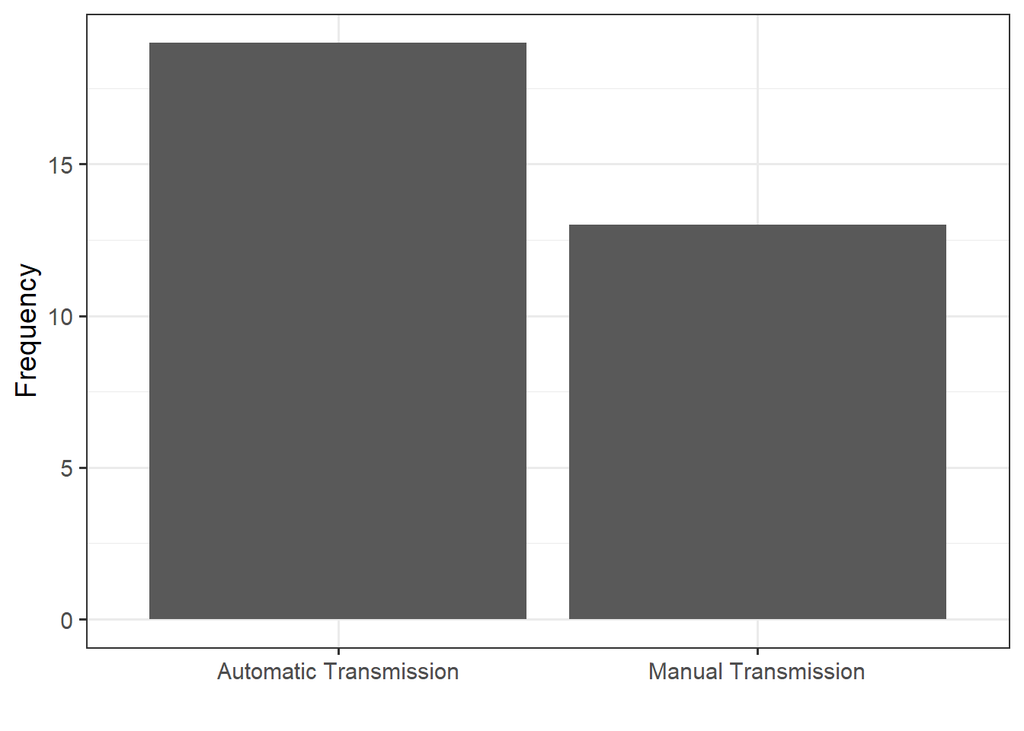

```r
qplot(data = mtcars,
      x = am,
      geom = "bar") +
  labs(x = "",
       y = "Frequency")
```

We remove the label on the x-axis because the value of the variable makes it clear what is being summarized.

## Multiple Categorical Variables: Bar Charts

If you have multiple categorical variables, consider using additional aesthetics to group variables. We will consider a bar chart summarizing the type of engine and the type of transmission for each vehicle. First, we clean up the way that the variable `vs` is coded:

```r
mtcars = mtcars %>%
  mutate(vs = recode(vs,
                     `0` = "V Engine",
                     `1` = "Straight Engine"))
```

Now, we construct the graphic using the following steps:

1. Place primary variable of interest on x-axis.
2. Use `fill =` to set the secondary variable.
3. Use `geom = "bar"`.

Again, we remove the labels of both the `fill` and the `x` variables because the values are self-evident.

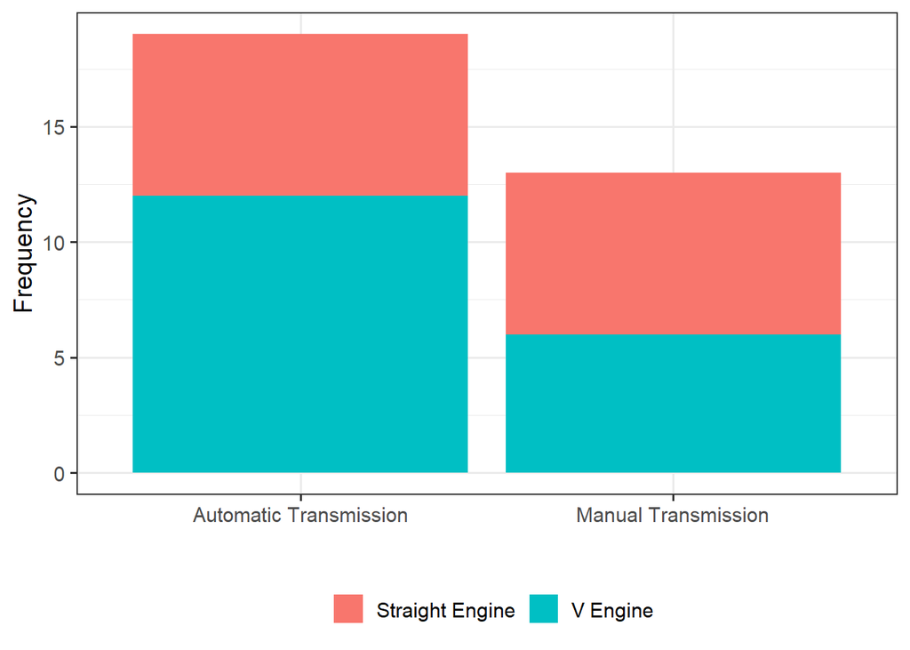

```r
qplot(data = mtcars,
      x = am,
      fill = vs,
      geom = "bar") +
  labs(x = "",
       fill = "",
       y = "Frequency")
```

## Quantitative Variable: Histogram

When looking at the distribution of a single variable, a histogram is a reasonable choice, especially for medium-sized datasets.

1. Set the variable to summarize on the x-axis.
2. Choose `geom = "histogram"`.
3. Set the `binwidth =` option to a reasonable size (how large do you want each bin to be). This changes for each problem and is a matter of opinion on what gives a reasonable looking graphic.

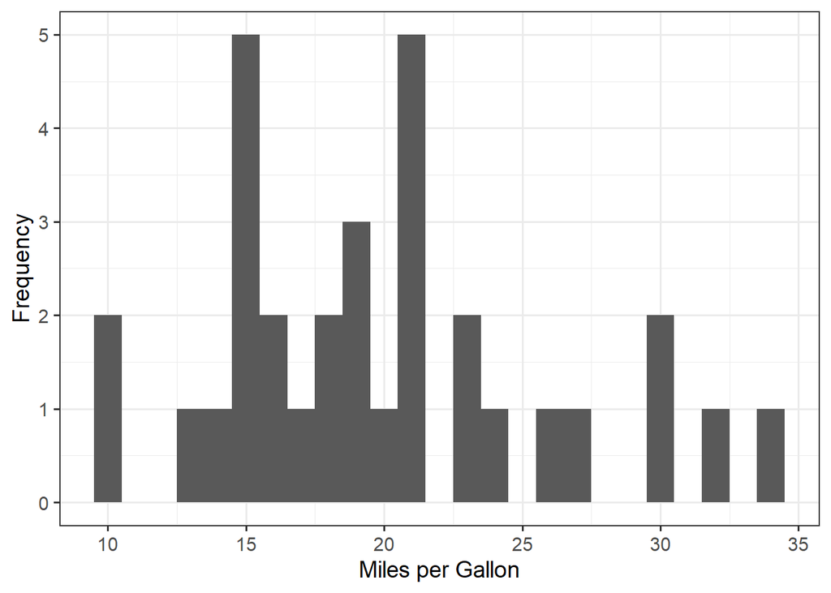

```r
qplot(data = mtcars,
      x = mpg,
      geom = "histogram",
      binwidth = 1) +
  labs(x = "Miles per Gallon",
       y = "Frequency")
```

In this graphic, we set the binwidth to be 1. We could also have considered a larger binwidth of 3, for example:

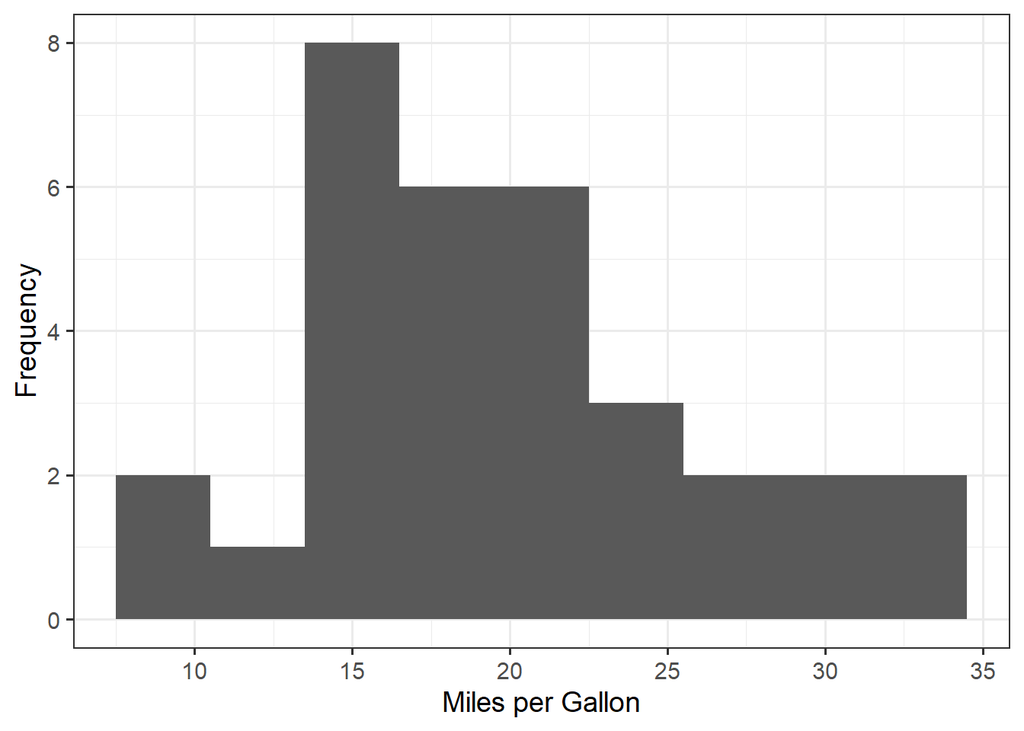

```r
qplot(data = mtcars,
      x = mpg,
      geom = "histogram",
      binwidth = 3) +
  labs(x = "Miles per Gallon",
       y = "Frequency")
```

If you exclude the `binwidth =` option, it will choose a value for you:

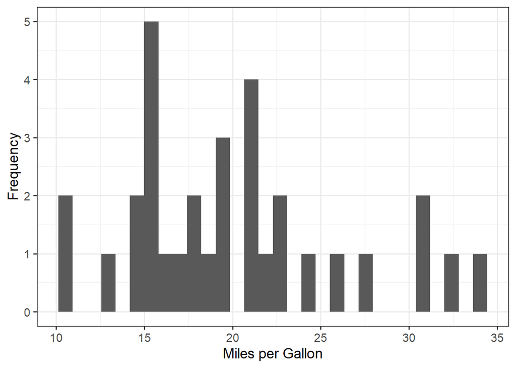

```r
qplot(data = mtcars,
      x = mpg,
      geom = "histogram") +
  labs(x = "Miles per Gallon",
       y = "Frequency")
```

## Quantitative Variable: Density

A density plot is like a smooth histogram; this works best with larger datasets.

1. Set the variable to summarize on the x-axis.
2. Choose `geom = "density"`

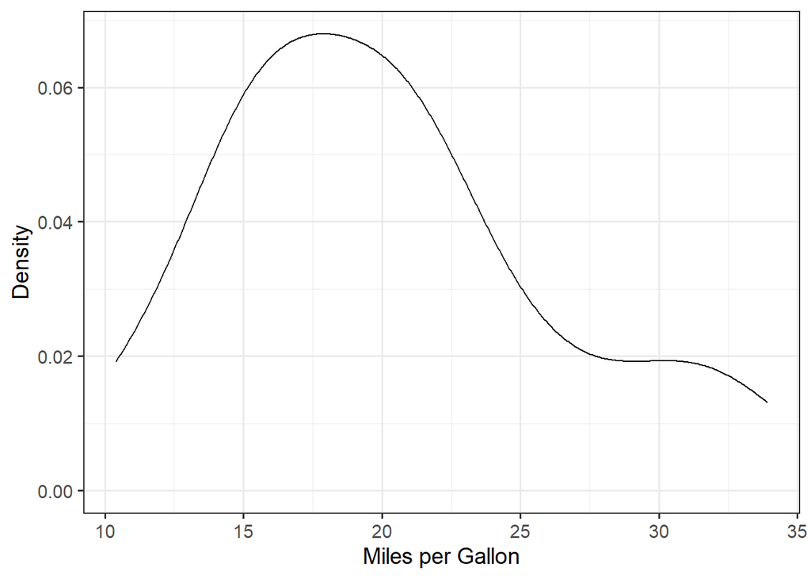

```r
qplot(data = mtcars,
      x = mpg,
      geom = "density") +
  labs(x = "Miles per Gallon",
       y = "Density")
```

The y-axis on this graphic is not directly interpretable; essentially they have been chosen such that the area under the curve is equal to 1. Our primary interest here is that larger values mean the values on the x-axis are more likely.

## Quantitative Variable: Boxplot

A boxplot gives a quick summary of location and spread for a numeric variable.

1. Set the variable to summarize on the y-axis.
2. Set the x-axis to be empty: "".
3. Choose `geom = "boxplot"`

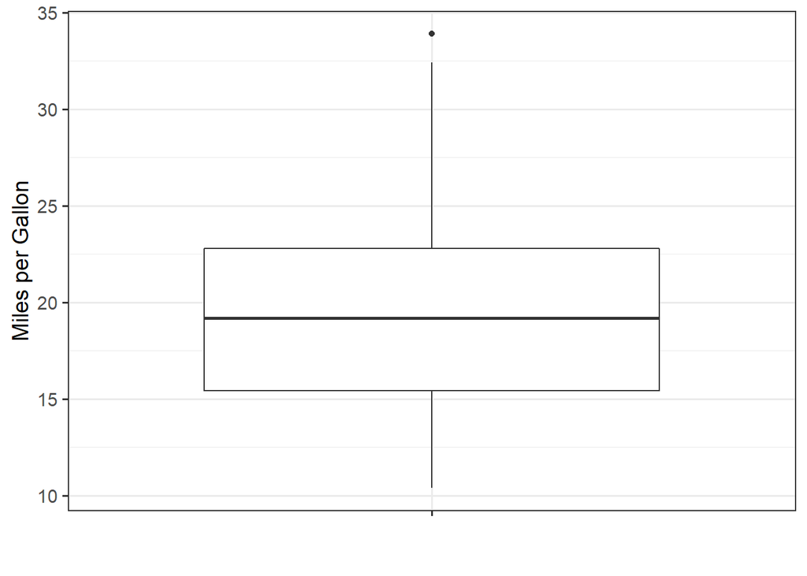

```r
qplot(data = mtcars,
      y = mpg,
      x = "",
      geom = "boxplot") +
  labs(y = "Miles per Gallon",
       x = "")
```

## Quantitative Variable Across Groups: Boxplots

If we are examining the distribution of a quantitative variable across various groups formed by a categorical variable, we can use side-by-side graphics, such as boxplots.

1. Set the variable to be summarized on the y-axis.
2. Place the grouping variable on the x-axis.
3. Set `geom = "boxplot"`.

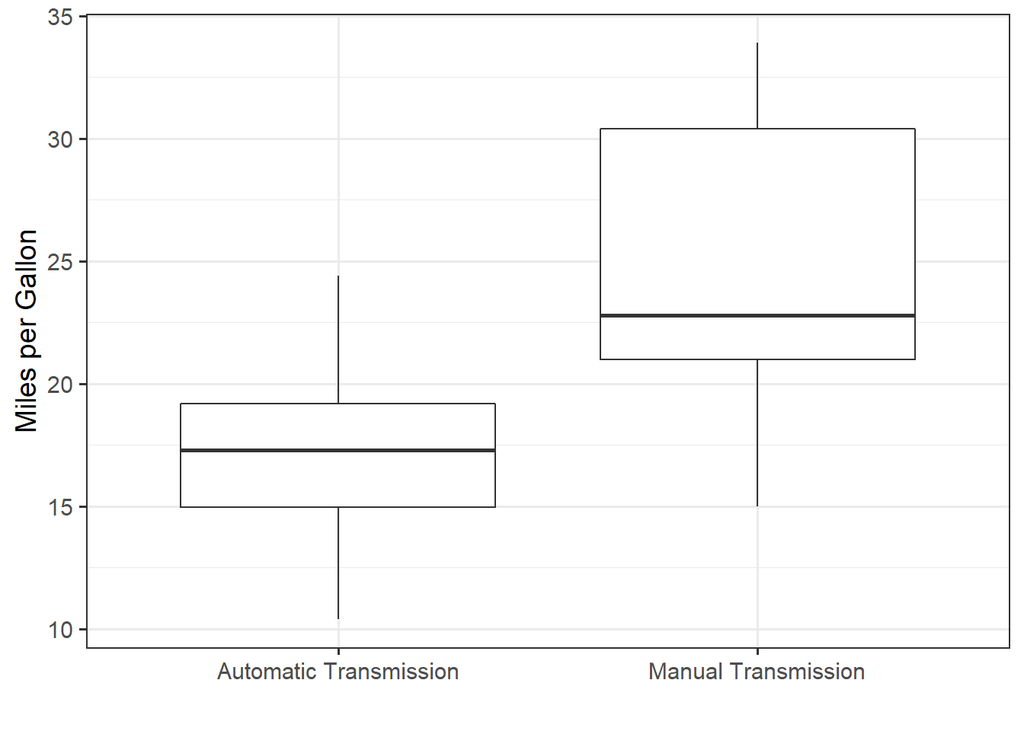

```r
qplot(data = mtcars,
      y = mpg,
      x = am,
      geom = "boxplot") +
  labs(x = "",
       y = "Miles per Gallon")
```

## Quantitative Variable Across Groups: Violin Plots

Boxplots summarize the center and spread of the data, but the shape is lost. Violin plots generalize boxplots by incorporating the shape.

1. Set the variable to be summarized on the y-axis.
2. Place the grouping variable on the x-axis.
3. Set `geom = "violin"`.

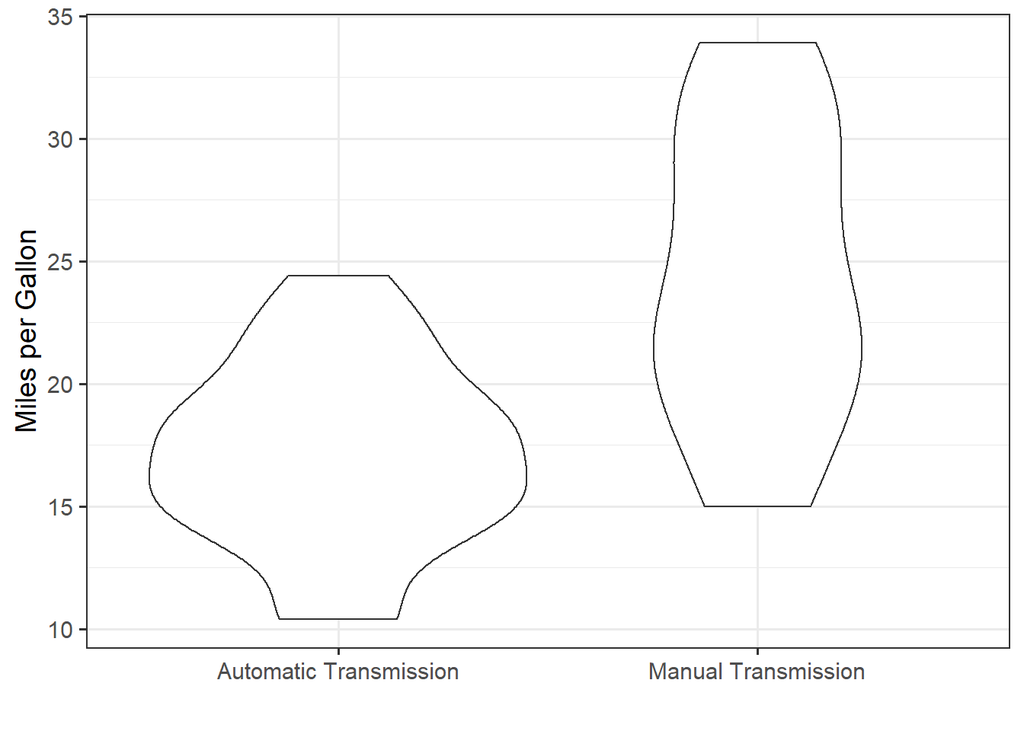

```r
qplot(data = mtcars,
      y = mpg,
      x = am,
      geom = "violin") +
  labs(x = "",
       y = "Miles per Gallon")
```

## Quantitative Variable Across Groups: Individual Value Plots

When we have a small sample, boxplots are inappropriate because they hide the raw data and present an overly confident summary. Instead, we prefer to place the raw values on the plot.

1. Set the variable to be summarized on the y-axis.
2. Place the grouping variable on the x-axis.
3. Set `geom = "point"`.

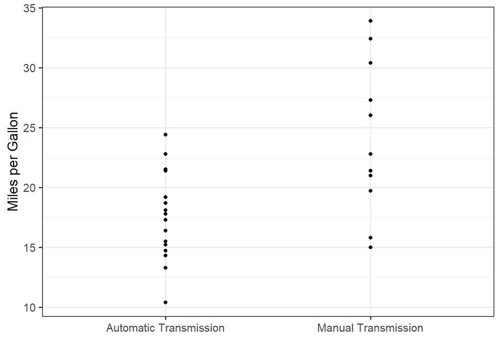

```r
qplot(data = mtcars,
      y = mpg,
      x = am,
      geom = "point") +
  labs(x = "",
       y = "Miles per Gallon")
```

If it looks too overwhelming because you have just enough points that they overlap, you can “jitter” the points:

1. Set the variable to be summarized on the y-axis.
2. Place the grouping variable on the x-axis.
3. Set `geom = "jitter"`.
4. Set `height = 0` to prevent the data from being jittered vertically.

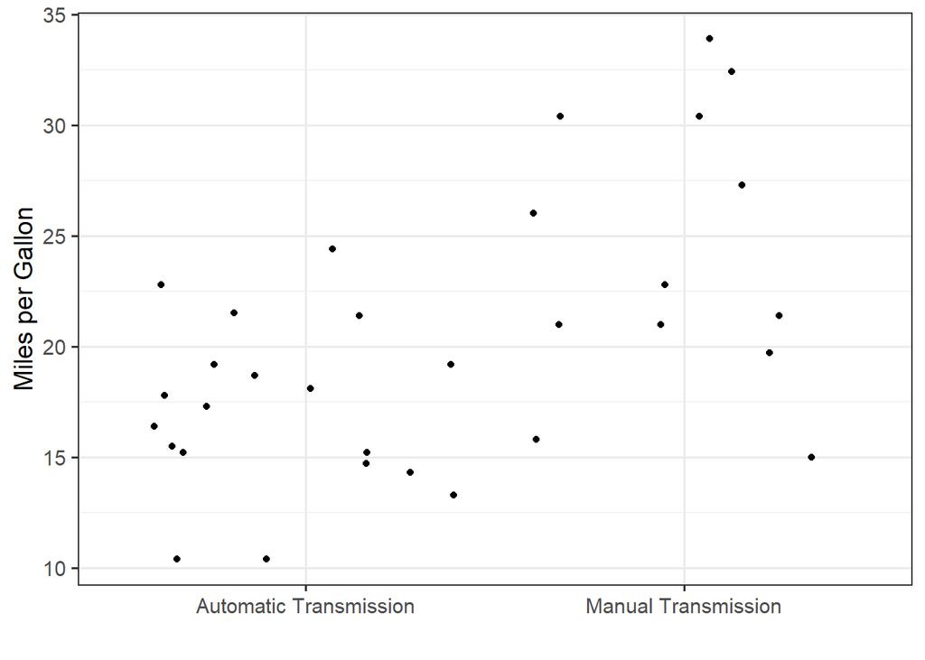

```r
qplot(data = mtcars,
      y = mpg,
      x = am,
      geom = "jitter",
      height = 0) +
  labs(x = "",
       y = "Miles per Gallon")
```

## Quantitative Variable Across Multiple Groups

Boxplots, Violin Plots, and Individual Value Plots can all be extended to include additional other groups by adding aesthetics. For example, we can construct a side-by-side boxplot which also fills according to the engine type.

1. Set variable to be summarized on the y-axis.
2. Set the primary grouping variable on the x-axis.
3. Set the secondary grouping variable as an aesthetic (`fill =`, `color =`, etc.)
4. Set `geom = "boxplot"` for example.

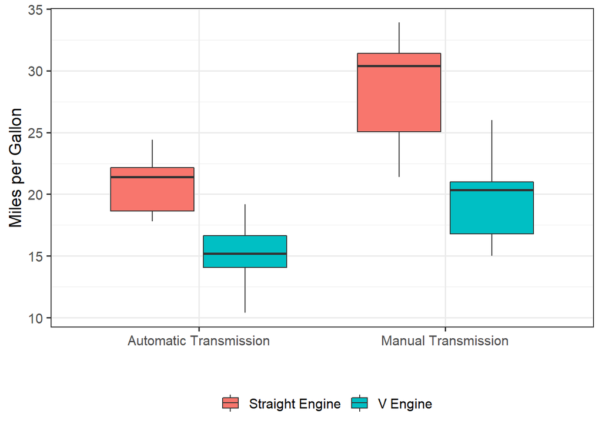

```r
qplot(data = mtcars,
      y = mpg,
      x = am,
      fill = vs,
      geom = "boxplot") +
  labs(x = "",
       y = "Miles per Gallon",
       fill = "")
```

## Two Quantitative Variables: Scatterplot

When examining the relationship between two quantitative variables, we can use a scatterplot.

1. Set the response (variable to be explained or predicted) on the y-axis.
2. Set the predictor (the “given” information) on the x-axis.
3. Set `geom = "point"`.

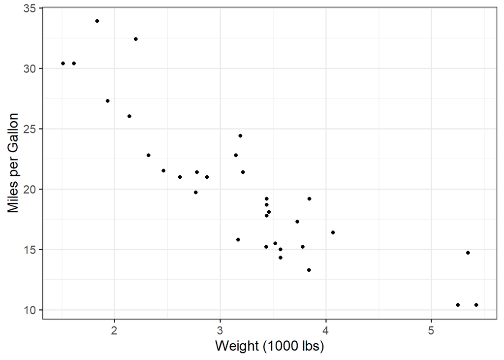

```r
qplot(data = mtcars,
      y = mpg,
      x = wt,
      geom = "point") +
  labs(y = "Miles per Gallon",
       x = "Weight (1000 lbs)")
```

## Adding Features to Scatterplots

Just as with other plots, we can add additional features to a scatterplot. In general, the following two guiding principles help when thinking about these additional aesthetics:

- Groups are best distinguished using color or shape.
- Quantitative variables are captured using color or size.

The following graphic examines the relationship between the fuel efficiency (MPG) of a vehicle and its weight, while also considering the transmission type of the vehicle. Since “transimission type” is categorical, we use the color to separate these groups.

1. Set the response (variable to be explained or predicted) on the y-axis.
2. Set the predictor (the “given” information) on the x-axis.
3. Set the grouping variable using `color =`.
4. Set `geom = "point"`.

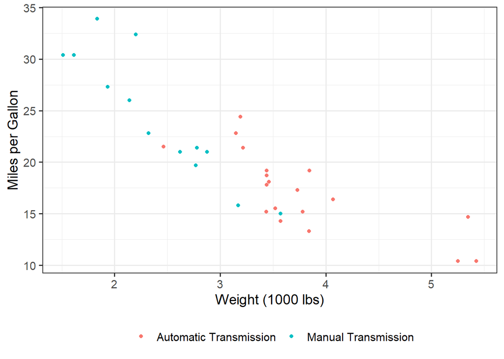

```r
qplot(data = mtcars,
      y = mpg,
      x = wt,
      color = am,
      geom = "point") +
  labs(y = "Miles per Gallon",
       x = "Weight (1000 lbs)",
       color = "")
```

We could also have used shape of the points instead.

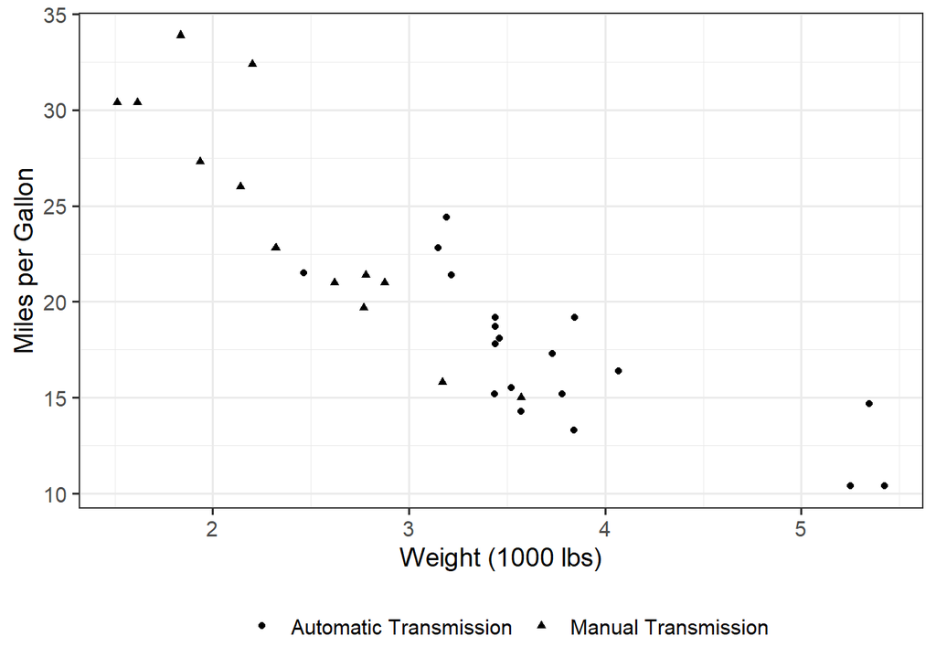

```r
qplot(data = mtcars,
      y = mpg,
      x = wt,
      shape = am,
      geom = "point") +
  labs(y = "Miles per Gallon",
       x = "Weight (1000 lbs)",
       shape = "")
```

If we want to look at the relationship between the fuel efficiency (MPG) of a vehicle and its weight, while also considering its horsepower, we do things a bit differently. Since “horsepower” is quantitative, we can use color or size to distinguish between various values. Both versions are shown below.

1. Set the response (variable to be explained or predicted) on the y-axis.
2. Set the predictor (the “given” information) on the x-axis.
3. Set the secondary predictor using `color =`.
4. Set `geom = "point"`.

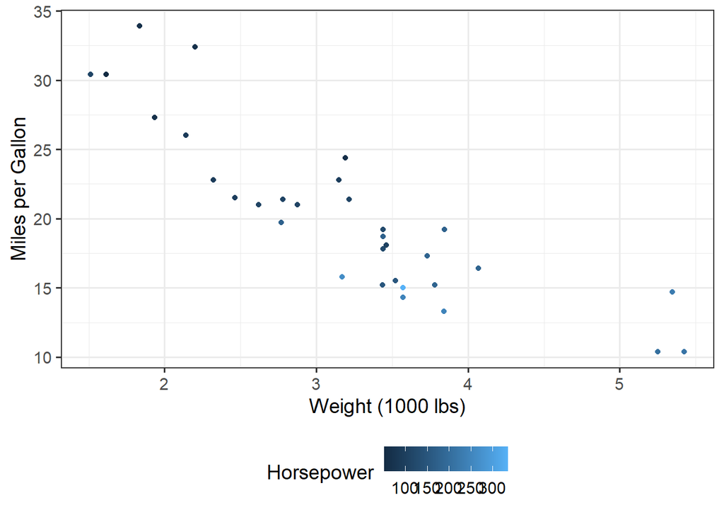

```r
qplot(data = mtcars,
      y = mpg,
      x = wt,
      color = hp,
      geom = "point") +
  labs(y = "Miles per Gallon",
       x = "Weight (1000 lbs)",
       color = "Horsepower")
```

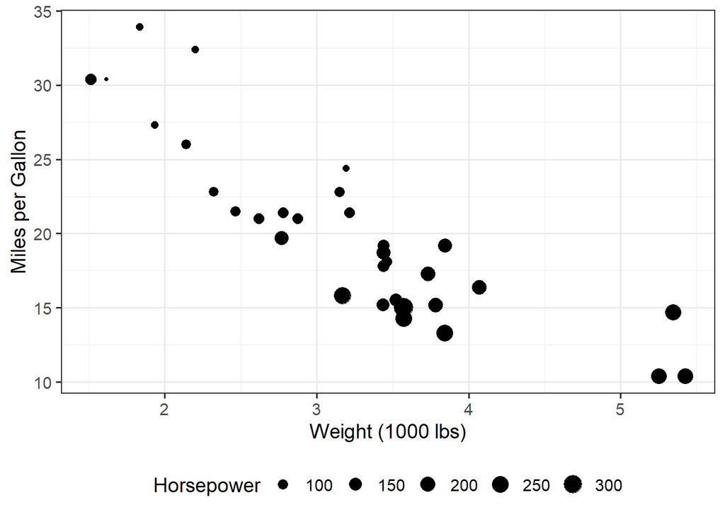

```r
qplot(data = mtcars,
      y = mpg,
      x = wt,
      size = hp,
      geom = "point") +
  labs(y = "Miles per Gallon",
       x = "Weight (1000 lbs)",
       size = "Horsepower")
```

# Specifying a Mean Model

Parameters in a population govern the data-generating process for a particular variable of interest. Throughout this course, we are focused on making inference on the mean response. For example, suppose we are interested in estimating the mean fuel efficiency; then, our model for the data generating process will have the form

$$(\text{MPG})_i = \mu + \epsilon_i$$

where $\mu$ is the parameter of interest (the average fuel efficiency). In order to communicate this data generating process to the computer, we use the function `specify_mean_model()` which makes use of the formula notation similar to when summarizing variables.

```r
mpg.model = specify_mean_model(mpg ~ 1, data = mtcars)
```

Here, the left-hand-side of the formula corresponds to the variable on the left-hand-side of the mathematical formula constructed above. The right-hand-side specifies the terms which contain a parameter. Since the $\mu$ in our mathematical model is alone, it is multiplied by a 1 (hence the 1 in the formula for the function). Again, we use the `data =` option in order to specify in which data set `mpg` can be found.

> Note: the error term is understood in the model and need not be communicated to the computer.

Finally, this mean model is something that we will be working with; so, it should be saved. Here, we save it under the name `mpg.model`.

# Confidence Interval for a Single Mean

We begin with the same mean model described in the previous section:

```r
mpg.model = specify_mean_model(mpg ~ 1, data = mtcars)
```

In order to construct a confidence interval, we use the `estimate_parameters()` function:

```r
estimate_parameters(mpg.model,
                    confidence.level = 0.95,
                    assume.identically.distributed = TRUE,
                    assume.normality = TRUE)
```

```
         term estimate standard.error 95% lower 95% upper
1 (Intercept) 20.09062       1.065424  17.91768  22.26357
```

This function has a few requirements:

1. You must specify the mean model containing the parameters of interest.
2. You must specify the confidence level for confidence intervals computed; failing to do this will result in only point estimates provided.
3. Specify whether certain conditions should be assumed.

Note that the computer will *always* assume the data is independent of one another and that the mean model is correctly specified.

Classical theory will be employed if both the normality and identically distributed conditions are assumed true. Otherwise, bootstrapping will be used to compute the confidence intervals. For example, to compute a 95% confidence interval using bootstrapping while assuming the fuel efficiency of each car comes from the same underlying distribution, use the following code:

```r
estimate_parameters(mpg.model,
                    confidence.level = 0.95,
                    assume.identically.distributed = TRUE,
                    assume.normality = FALSE)
```

```
         term estimate standard.error 95% lower 95% upper
1 (Intercept) 20.09062       1.038145  18.10922  22.17812
```

Remember that each time you use a bootstrap procedure, the model for the sampling distribution will change slightly due to randomness. Therefore, the endpoints of the interval may very slightly. In order to prevent this, you can “set a seed” for random number generation. Think of this as specifying how the random number generator should begin. Running the same block of code multiple times will produce the same ouptut.

```r
set.seed(123)
estimate_parameters(mpg.model,
                    confidence.level = 0.95,
                    assume.identically.distributed = TRUE,
                    assume.normality = FALSE)
```

```
         term estimate standard.error 95% lower 95% upper
1 (Intercept) 20.09062       1.061347  18.05625  22.15672
```

The seed value can be any integer.

## Examining sampling distribution graphically.

If you want to examine the entire model for the sampling distribution graphically (instead of just having the CI), you must first save the output of the `estimate_parameters()` function and then use it in the `plot_sampling_distribution()` function. Below is the plot of the model for the sampling distribution of the sample mean fuel efficiency when we do not assume normality. Here, the results of `estimate_parameters()` is stored in the name `sampling.distn` which can be used later on.

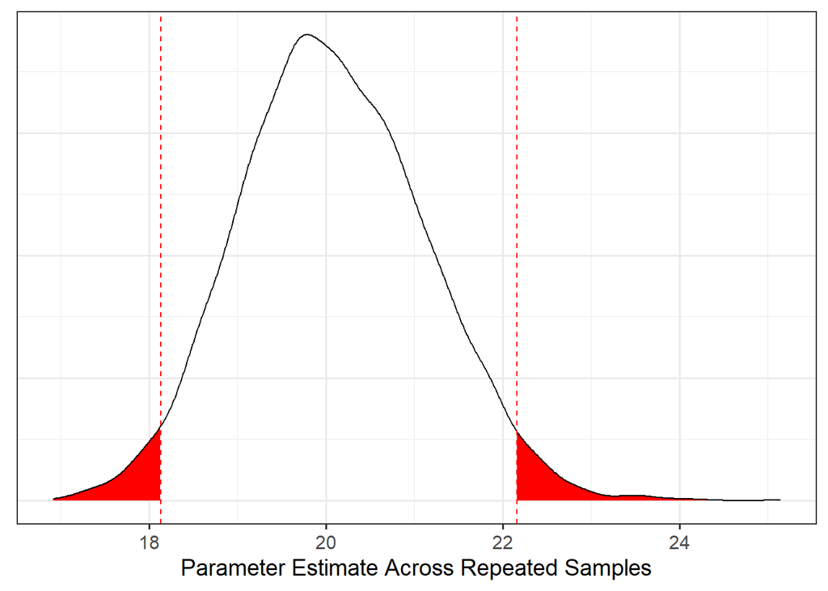

```r
sampling.distn = estimate_parameters(mpg.model,
                                     confidence.level = 0.95,
                                     assume.identically.distributed = TRUE,
                                     assume.normality = FALSE)

plot_sampling_distribution(sampling.distn,
                           show.confidence.interval = TRUE)
```

We can optionally choose to illustrate the confidence interval on the plot, which can be printed by printing out the contents of `sampling.distn`, which just holds the result of the call to the `estimate_parameters()` function:

```r
sampling.distn
```

```
         term estimate standard.error 95% lower 95% upper
1 (Intercept) 20.09062       1.039801  18.13406  22.16281
```

# P-values for Mean

We begin with the same mean model
$$(\text{MPG})_i = \mu + \epsilon_i$$
Suppose we are interested in testing the hypothesis
$$H_0: \mu = 18 \qquad \text{vs.} \qquad H_1: \mu \neq 18$$

Hypothesis testing at its core is about comparing two models: a full (unrestricted) model (alternative hypothesis) and a restricted model (null hypothesis). Specifically, notice that under the alternative hypothesis, we have
$$\text{Unrestricted Model:} \quad (\text{MPG})_i = \mu + \epsilon_i$$

This is easily communicated to the computer:

```r
mpg.model.h1 = specify_mean_model(mpg ~ 1, data = mtcars)
```

Under the null hypothesis, we have
$$\text{Restricted Model:} \quad (\text{MPG})_i = 18 + \epsilon_i$$

In this restricted model, there are no parameters to estimate. Instead, the parameter has a specific constant value. When specifying this model, we need to use the `constant()` notation to signify this.

```r
mpg.model.h0 = specify_mean_model(mpg ~ constant(18), data = mtcars)
```

Now, the two models can be compared:

```r
compare_models(mpg.model.h1,
               mpg.model.h0,
               assume.identically.distributed = TRUE,
               assume.normality = TRUE)
```

```
            source df        ss       ms statistic    p.value
1 Additional Terms  1  139.8628 139.8628  3.850413 0.05876422
2            Error 31 1126.0472  36.3241        NA         NA
```

## Examining null distribution graphically.

If you want to examine the entire model for the null distribution graphically (instead of just having the p-value), you must first save the output of the `compare_models()` function and then use it in the `plot_null_distribution()` function. Below is the plot of the model for the null distribution of the statistic summarizing the evidence against the null hypothesis described above. Here, the results of `compare_models()` is stored in the name `null.distn` which can be used later on.

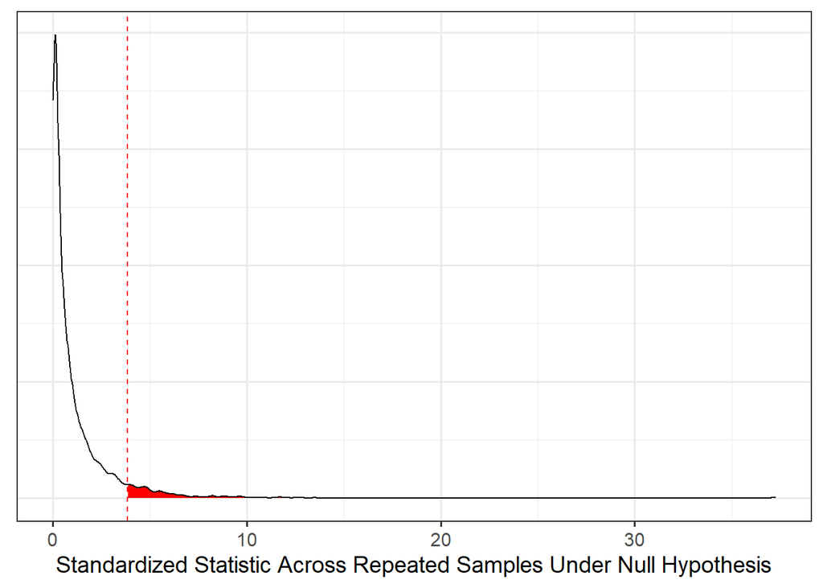

```r
null.distn = compare_models(mpg.model.h1,
               mpg.model.h0,
               assume.identically.distributed = TRUE,
               assume.normality = FALSE)

plot_null_distribution(null.distn,
                       show.pvalue = TRUE)
```

We can optionally choose to illustrate the region which will make up the p-value, which can be printed by printing out the contents of `null.distn`, which just holds the result of the call to the `compare_models()` function:

```r
null.distn
```

```
            source df        ss       ms statistic p.value
1 Additional Terms  1  139.8628 139.8628  3.850413  0.0646
2            Error 31 1126.0472  36.3241        NA      NA
```